# Assignment 3 - Kickstarter Projects

Taketo Muroya

```r
# Setting up
library(RColorBrewer)
library(ggplot2)
library(ggthemes)
library(tidyverse)
library(tidytext)
library(dplyr)
library(tm)
library(SnowballC)
library(wordcloud)
library(plotrix)
```

## 1. Identifying Successful Projects

### a) Success by Category

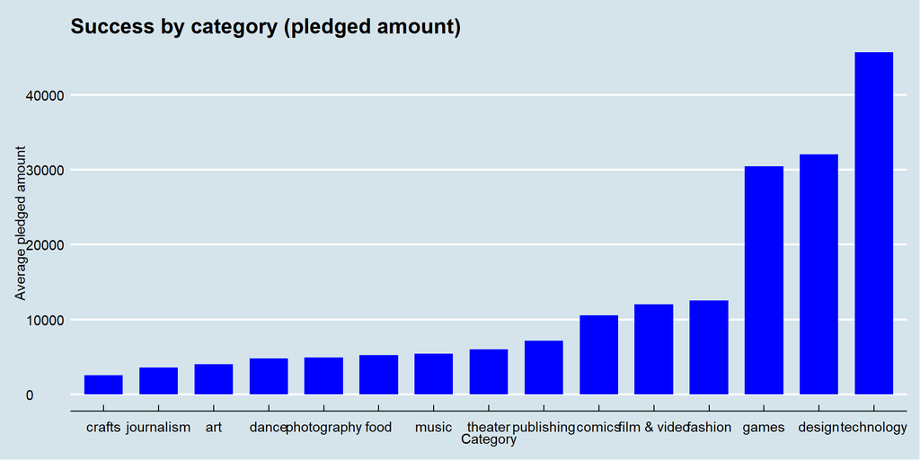

```r
# load dataset
data_raw <- read.csv("kickstarter_projects_2020_02.csv",
                     stringsAsFactors=FALSE)

# clean data
data_raw$pledged <- as.numeric(data_raw$pledged)
data0 <- subset(data_raw, data_raw$pledged != 'NA')
data0$backers_count <- as.numeric(data0$backers_count)
data1 <- subset(data0, data0$backers_count != 'NA')
data2 <- subset(data1, data1$staff_pick == 'TRUE')
data3 <- subset(data1, data1$staff_pick == 'FALSE')
data4 <- rbind(data2, data3)
data5 <- subset(data4, data4$spotlight == 'TRUE')
data6 <- subset(data4, data4$spotlight == 'FALSE')
data <- rbind(data5, data6)

# create achievement_ratio
data$achievement_ratio <-
  round(100*as.numeric(data$pledged)/as.numeric(data$goal),1)

# visualize
ggplot(data, aes(reorder(top_category, pledged, mean), pledged)) +
  stat_summary(fun=mean, geom="bar", fill="blue", width=0.7) +
  xlab("Category") + ylab("Average pledged amount") +
  ggtitle("Success by category (pledged amount)") + theme_economist()
```

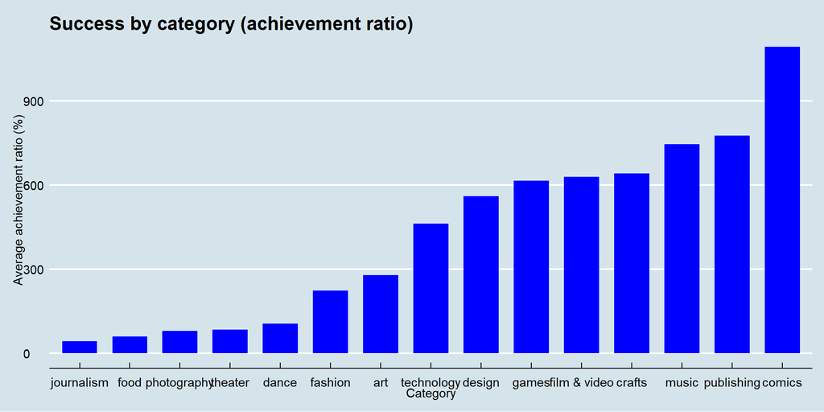

```r
ggplot(data, aes(reorder(top_category, achievement_ratio, mean),
                 achievement_ratio)) + theme_economist() +
  stat_summary(fun=mean, geom="bar", fill="blue", width=0.7) +
  xlab("Category") + ylab("Average achievement ratio (%)") +
  ggtitle("Success by category (achievement ratio)")
```

#### **Comment:** Based on the measurement of pledged amount, technology, design, and games are very successful projects. However, the absolute values of pledged amount may not represent the degree of success properly because these top 3 projects seem like relatively large-scale projects. Thus, the achievement ratio shows the different result, saying that comics, publishing, and music are very successful projects.

## 2. Writing your success story

### a) Cleaning the Text and Word Cloud

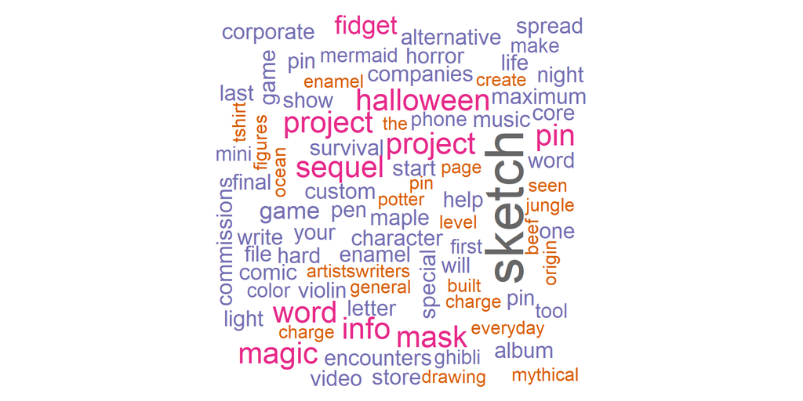

```r
# pick up success and non-success data
top <- subset(data, data$achievement_ratio >= 1184)
top$doc_id <- paste(top$id, "top", sep = "_")
worst_temp <- subset(data, data$pledged == 0)
set.seed(1234)
worst <- sample_n(tbl=worst_temp, size=1000)
worst$doc_id <- paste(worst$id, "worst", sep = "_")
df <- rbind(top, worst)

# Remove fully capitalized words
for (i in 1:nrow(df)){
  df$blurb[i] <- gsub("(?:[A-Z]+){2,}","", df$blurb[i])
}

# create corpus
df_temp <- df[,c(26,2)]
colnames(df_temp) <- c("doc_id", "text")
df_source <- DataframeSource(df_temp)
df_corpus <- VCorpus(df_source)

# cleaning text
clean_corpus <- function(corpus){
  corpus <- tm_map(corpus, removePunctuation)
  corpus <- tm_map(corpus, removeWords, c(stopwords("en")))
  corpus <- tm_map(corpus, removeNumbers)
  corpus <- tm_map(corpus, stripWhitespace)
  return(corpus)
}
df_clean <- clean_corpus(df_corpus)

# Stemming text
df_stemmed <- tm_map(df_clean, stemDocument)

# Completing text
stemCompletion2 <- function(x, dictionary) {
   x <- unlist(strsplit(as.character(x), " "))
   x <- x[x != ""]
   x <- stemCompletion(x, dictionary=dictionary)
   x <- paste(x, sep="", collapse=" ")
   #PlainTextDocument(stripWhitespace(x))
   x <- stripWhitespace(x)
   x
}

for (i in 1:nrow(df)){
  df_temp$text[i]<-stemCompletion2(df_stemmed[[i]]$content, df_clean)
}
df_source <- DataframeSource(df_temp)
df_comp <- VCorpus(df_source)

# create the dtm and tdm from the corpus
df_dtm <- DocumentTermMatrix(df_comp)
df_tdm <- TermDocumentMatrix(df_comp)
m_dtm <- as.matrix(df_dtm)
m_tdm <- as.matrix(df_tdm)

# tidy object
df_td <- tidy(df_tdm)
meta <- as_data_frame(str_split_fixed(df_td$document, "_", n=2))
colnames(meta) <- c("id", "status")
df_td <- as_data_frame(cbind(df_td, meta))

# calculate tf_idf
df_tfidf <- df_td %>%
  bind_tf_idf(term, document, count) %>%
  arrange(desc(tf_idf))

# subset top data
top_tfidf <- subset(df_tfidf, df_tfidf$status=="top")

# create a wordcloud for the values in word_freqs
set.seed(1234)
wordcloud(top_tfidf$term, top_tfidf$tf,
          max.words=100, colors=brewer.pal(8, "Dark2"))
```

### b) Success in words

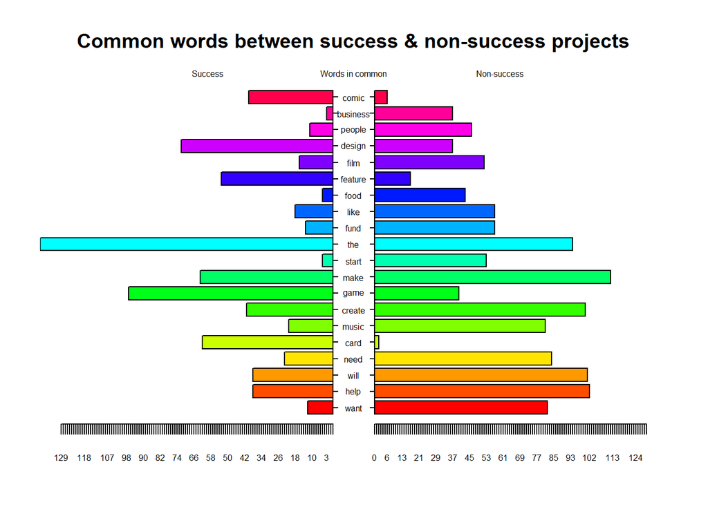

```r
# combine top and worst data
sum_top <- 0
sum_worst <- 0
for (i in 1:nrow(m_tdm)){
  sum_top[i] <- sum(m_tdm[i,1:nrow(top)])
  sum_worst[i] <- sum(m_tdm[i,(nrow(top)+1):(nrow(top)+nrow(worst))])
}
sum <- cbind(sum_top, sum_worst)
sum <- data.frame(sum,row.names=rownames(m_tdm))

# create common_words
common_words <- subset(sum, sum[,1] > 0 & sum[,2] > 0)
difference <- abs(common_words[,1] - common_words[,2])
common_words <- cbind(common_words, difference)
common_words <- common_words[order(common_words[,3], decreasing = TRUE), ]

# create top20
top20 <- data.frame(x = common_words[1:20,1],
                    y = common_words[1:20,2],
                    labels = rownames(common_words[1:20,]))

# create the pyramid plot
p <- pyramid.plot(top20$x, top20$y, labels = top20$labels, gap = 10,
                  top.labels=c("Success", "Words in common", "Non-success"),
                  main="Common words between success & non-success projects",
                  laxlab = NULL, raxlab = NULL, unit = NULL, labelcex=0.5)
```

### c) Simplicity as a virtue

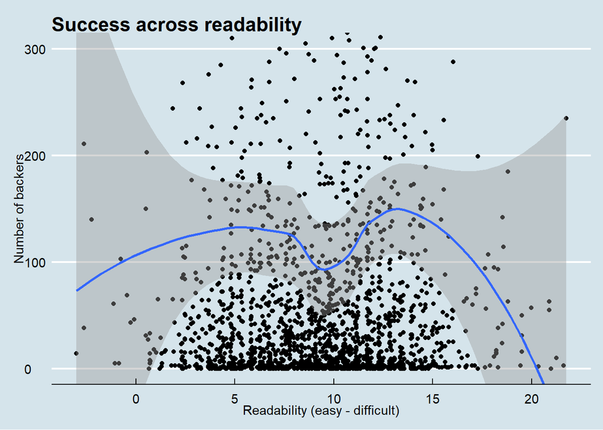

```r
# random sampling from master data
set.seed(1234)
sample <- sample_n(tbl=data, size=2000)
sample <- sample[-1394,]
d_temp <- sample[,c(10,2)]
colnames(d_temp) <- c("doc_id", "text")
d_source <- DataframeSource(d_temp)
d_corpus <- VCorpus(d_source)

# calculate readability
require(quanteda)
require(dplyr)
df_cor <- corpus(d_corpus)
df_FRE <- textstat_readability(df_cor, measure=c('Flesch.Kincaid'))
FRE <- cbind(df_FRE, sample$backers_count)
FRE <- FRE[-1082,]
colnames(FRE) <- c("doc", "FRE", "success")

# visualize
ggplot(FRE) + geom_point(aes(FRE, success)) + theme_economist() +
  stat_smooth(aes(FRE, success), formula=y~x, method="loess") +
  xlab("Readability (easy - difficult)") + ylab("Number of backers") +
  ggtitle("Success across readability") + coord_cartesian(ylim=c(0, 300))
```

#### **Comment:** From the relationship between the number of backers and the readability of project sentences, too simple or too complicated sentences could result in less success projects.

## 3. Sentiment

### a) Stay positive

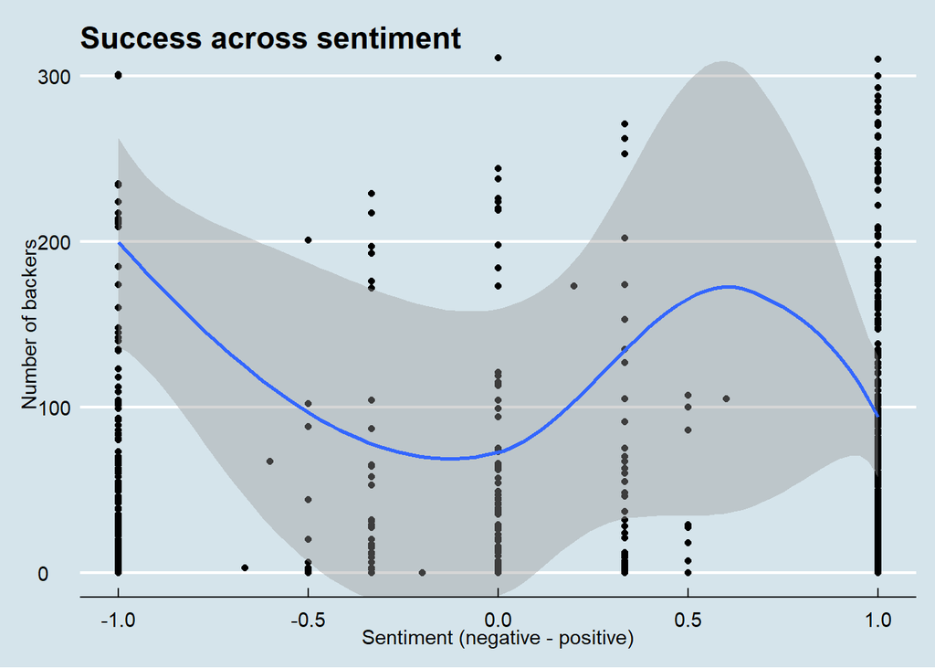

```r
# random sampling
set.seed(1234)
sample <- sample_n(tbl=data, size=2000)

# get sentiment score
pos <- read.table("dictionaries/positive-words.txt", as.is=T)
neg <- read.table("dictionaries/negative-words.txt", as.is=T)

sentiment <- function(words){
  require(quanteda)
  tok <- quanteda::tokens(words)
  pos.count <- sum(tok[[1]]%in%pos[,1])
  neg.count <- sum(tok[[1]]%in%neg[,1])
  out <- (pos.count-neg.count)/(pos.count+neg.count)
  out
}

sen <- 0
for (i in 1:nrow(sample)){
  sen[i] <- sentiment(sample$blurb[i])
}

# combine sentiment and success measurement
df_sen <- data.frame(cbind(sen, sample$backers_count))
colnames(df_sen) <- c("sentiment", "success")

# visualize
ggplot(df_sen) + geom_point(aes(sentiment, success)) +
  stat_smooth(aes(sentiment, success), formula=y~x, method="loess") +
  xlab("Sentiment (negative - positive)") + ylab("Number of backers") +
  ggtitle("Success across sentiment") + coord_cartesian(ylim=c(0, 300)) +
  theme_economist()
```

#### **Comment:** The relationship between sentiment and the number of backers is not linear. The very negative sentences could get many backers, but they lose backers as they become neutral. And then, the projects get more backers as they have more positive sentiments. However, after around 0.5 score of sentiment, the number of backers goes down again.

### b) Positive vs negative

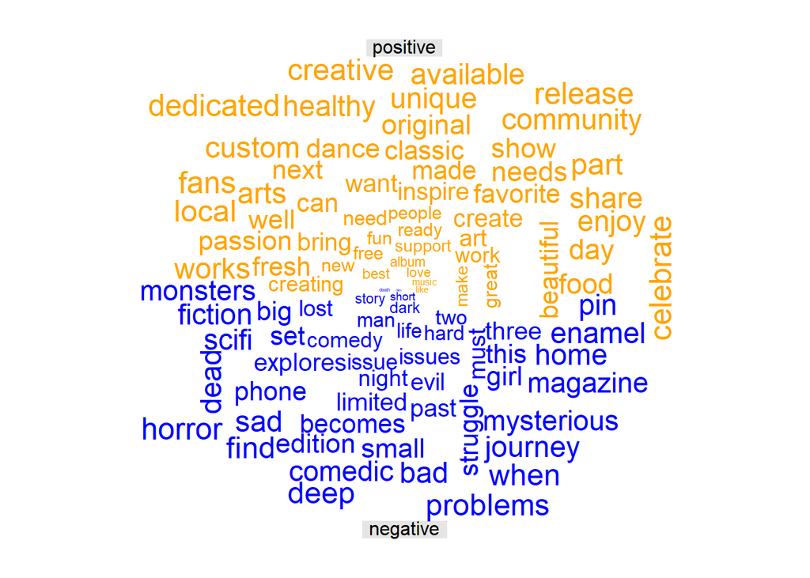

```r
# combine sentiment and text
data_sen <- data.frame(cbind(sample$blurb, df_sen))
colnames(data_sen) <- c("text", "sentiment", "success")

# find positive and negative text
positive <- subset(data_sen, sentiment > 0)
negative <- subset(data_sen, sentiment < 0)

p_text <- list()
for (i in 1:nrow(positive)){
  p_text <- paste(p_text, positive$text[i], sep = " ")
}
n_text <- list()
for (i in 1:nrow(negative)){
  n_text <- paste(n_text, negative$text[i], sep = " ")
}

# create corpus
pn_temp <- data.frame(c("positive","negative"), c(p_text, n_text))
colnames(pn_temp) <- c("doc_id", "text")
pn_source <- DataframeSource(pn_temp)
pn_corpus <- VCorpus(pn_source)
pn_clean <- clean_corpus(pn_corpus)

# create the dtm and tdm from the corpus
pn_dtm <- DocumentTermMatrix(pn_clean)
pn_tdm <- TermDocumentMatrix(pn_clean)
m_pn_dtm <- as.matrix(pn_dtm)
m_pn_tdm <- as.matrix(pn_tdm)

# Create comparison cloud
comparison.cloud(m_pn_tdm, colors = c("orange", "blue"),
                 scale=c(0.1,2), title.size= 1, max.words = 100)
```

### c) Get in their mind

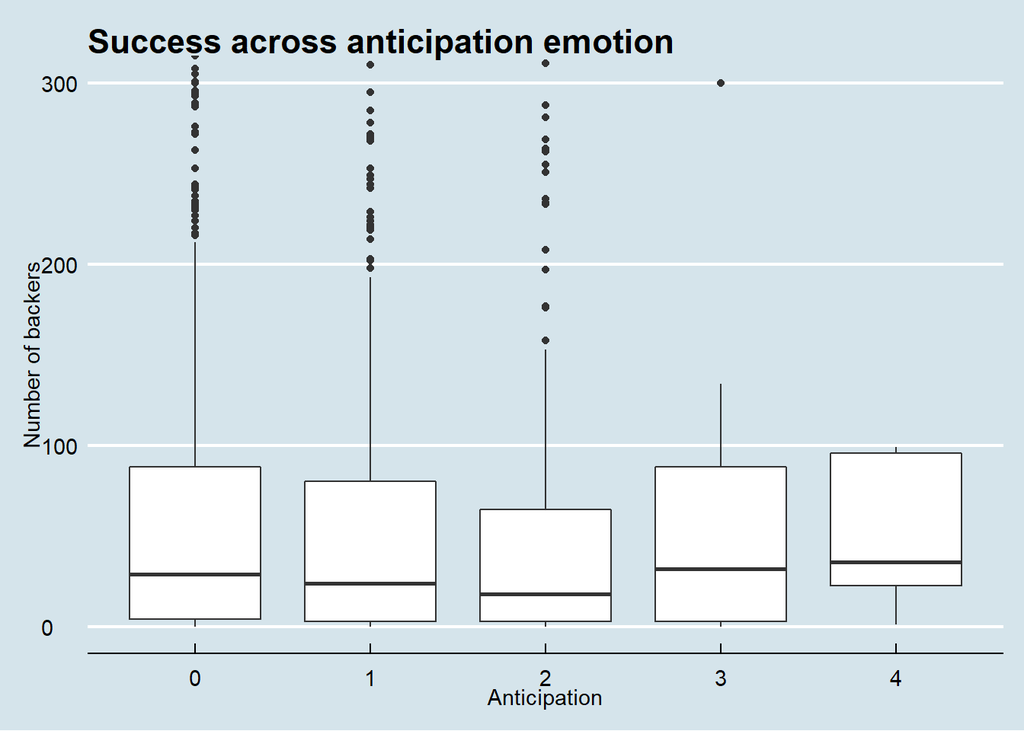

```r
#library(remotes)
#install_github("EmilHvitfeldt/textdata")
#install_github("juliasilge/tidytext")

# prepare emotion dictionary
dic <- get_sentiments("nrc")
anger <- subset(dic$word, dic$sentiment=="anger")
anticipation <- subset(dic$word, dic$sentiment=="anticipation")
disgust <- subset(dic$word, dic$sentiment=="disgust")
fear <- subset(dic$word, dic$sentiment=="fear")
joy <- subset(dic$word, dic$sentiment=="joy")
sadness <- subset(dic$word, dic$sentiment=="sadness")
surprise <- subset(dic$word, dic$sentiment=="surprise")
trust <- subset(dic$word, dic$sentiment=="trust")

# measure emotion score
emotion <- function(words){
  require(quanteda)
  tok <- quanteda::tokens(words)
  anticipation.c <- sum(tok[[1]]%in%anticipation)
  joy.c <- sum(tok[[1]]%in%joy)
  trust.c <- sum(tok[[1]]%in%trust)
  surprise.c <- sum(tok[[1]]%in%surprise)
  anger.c <- sum(tok[[1]]%in%anger)
  disgust.c <- sum(tok[[1]]%in%disgust)
  fear.c <- sum(tok[[1]]%in%fear)
  sadness.c <- sum(tok[[1]]%in%sadness)
  out <- data.frame(anticipation.c, joy.c, trust.c, surprise.c,
                    anger.c, disgust.c, fear.c, sadness.c)
  out
}

emo <- emotion(sample$blurb[1])
for (i in 2:nrow(sample)){
  emo <- rbind(emo, emotion(sample$blurb[i]))
}

# combine emotion and success measurement
df_emo <- data.frame(cbind(emo, sample$backers_count))
colnames(df_emo) <- c("anticipation", "joy", "trust", "surprise",
                      "anger", "disgust", "fear", "sadness", "success")

# visualize
ggplot(df_emo)+geom_boxplot(aes(anticipation,success,group=anticipation)) +
  xlab("Anticipation") + ylab("Number of backers") +
  ggtitle("Success across anticipation emotion") +
  coord_cartesian(ylim=c(0, 300)) + theme_economist()
```

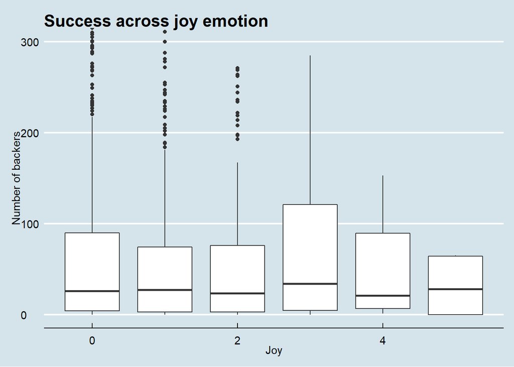

```r
ggplot(df_emo) + geom_boxplot(aes(joy, success, group=joy)) +
  xlab("Joy") + ylab("Number of backers") +
  ggtitle("Success across joy emotion") +
  coord_cartesian(ylim=c(0, 300)) + theme_economist()
```

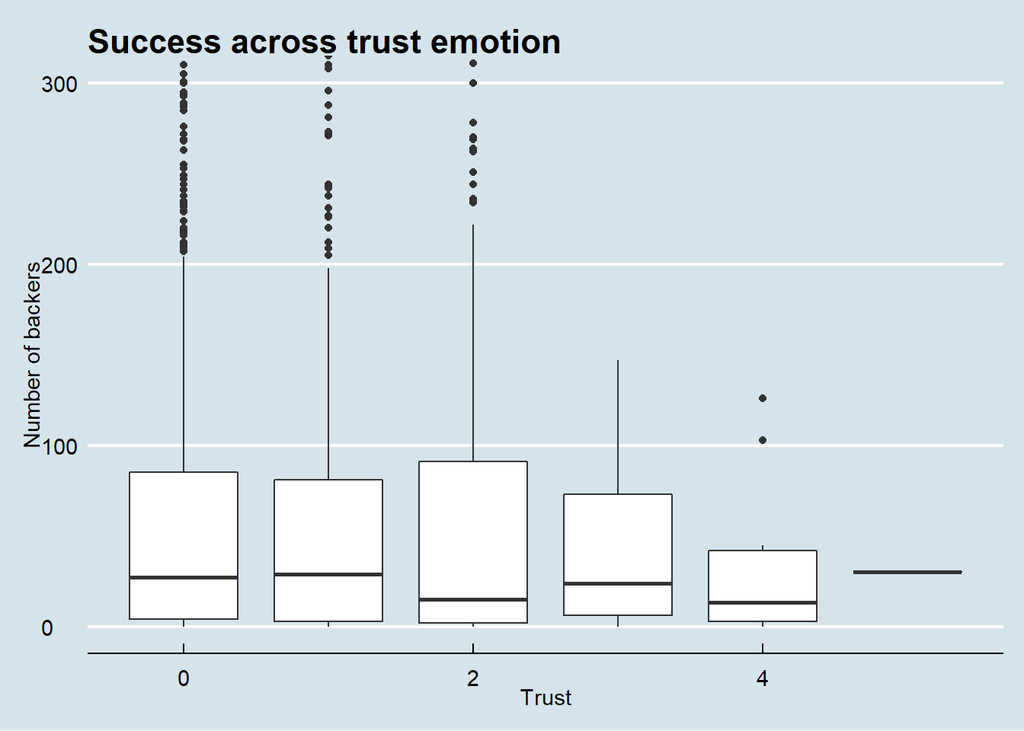

```r
ggplot(df_emo) + geom_boxplot(aes(trust, success, group=trust)) +
  xlab("Trust") + ylab("Number of backers") +
  ggtitle("Success across trust emotion") +
  coord_cartesian(ylim=c(0, 300)) + theme_economist()
```

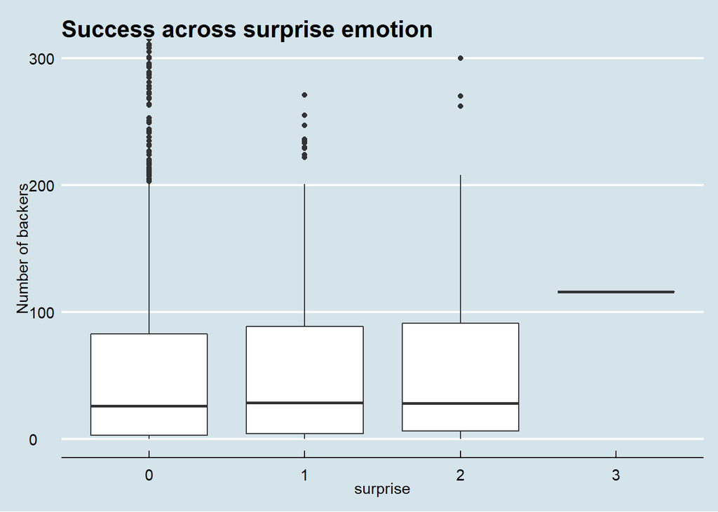

```r
ggplot(df_emo) + geom_boxplot(aes(surprise, success, group=surprise)) +
  xlab("surprise") + ylab("Number of backers") +
  ggtitle("Success across surprise emotion") +
  coord_cartesian(ylim=c(0, 300)) + theme_economist()
```

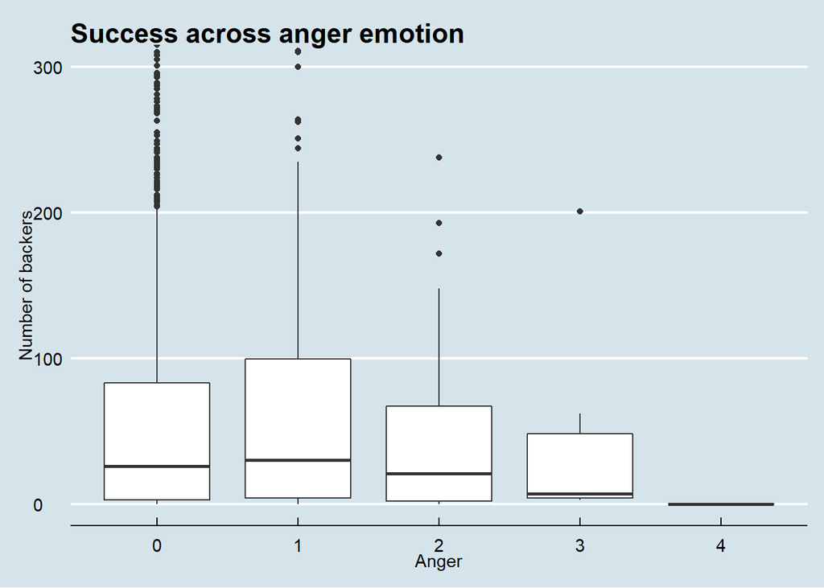

```r
ggplot(df_emo) + geom_boxplot(aes(anger, success, group=anger)) +
  xlab("Anger") + ylab("Number of backers") +
  ggtitle("Success across anger emotion") +
  coord_cartesian(ylim=c(0, 300)) + theme_economist()
```

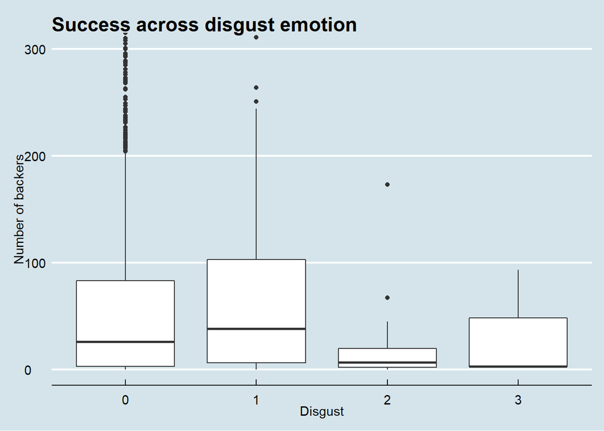

```r
ggplot(df_emo) + geom_boxplot(aes(disgust, success, group=disgust)) +
  xlab("Disgust") + ylab("Number of backers") +
  ggtitle("Success across disgust emotion") +
  coord_cartesian(ylim=c(0, 300)) + theme_economist()
```

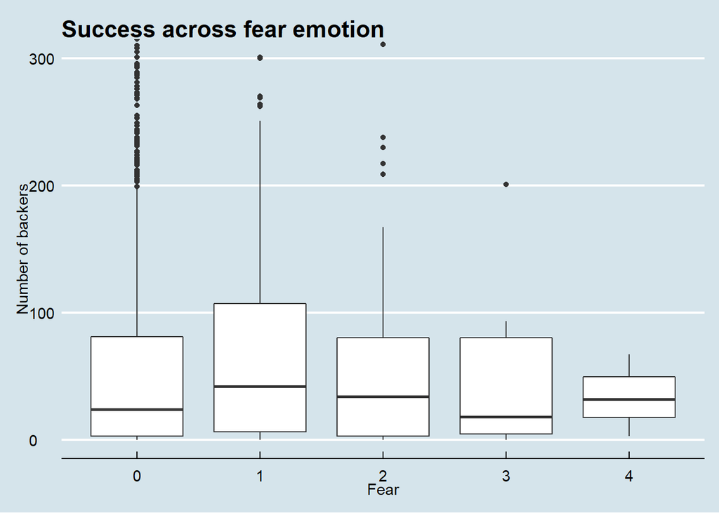

```r
ggplot(df_emo) + geom_boxplot(aes(fear, success, group=fear)) +
  xlab("Fear") + ylab("Number of backers") +
  ggtitle("Success across fear emotion") +
  coord_cartesian(ylim=c(0, 300)) + theme_economist()
```

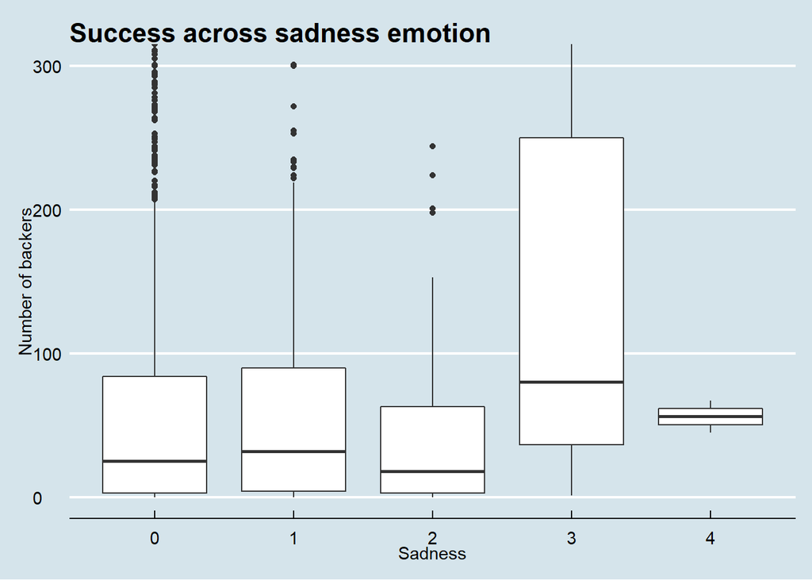

```r
ggplot(df_emo) + geom_boxplot(aes(sadness, success, group=sadness)) +
  xlab("Sadness") + ylab("Number of backers") +
  ggtitle("Success across sadness emotion") +
  coord_cartesian(ylim=c(0, 300)) + theme_economist()
```

#### **Comment:** The large sadness emotion could help the projects get more backers. On the other hand, the anger and disgust emotion could reduce the chance to get backers. The other emotions are not clear about it.